# Course: Visual Analytics for Policy and Management

## Assignment 3: Multivariate plot

### By Nathan Anderson-Hobbs, Johnson Nguyen, Kim Pearson & Marcela VÃ¡zquez

```r
# loading the data source and opening libraries
link='https://github.com/marcevl/Team-Assignments/raw/master/Internet2.RData'
load(file=url(link))
library(ggplot2)
```

```r
library(dotwhisker)
library(broom)
library(dplyr)

# creating first model of regression for Download and Upload Speeds on Satisfaction with Speed
model1=lm(Satisfaction.Speed~Download.Speed+Upload.Speed,data=Internet2[,-1])
summary(model1)
```

```
##
## Call:
## lm(formula = Satisfaction.Speed ~ Download.Speed + Upload.Speed,
##     data = Internet2[, -1])
##
## Residuals:
##     Min      1Q  Median      3Q     Max
## -2.4111 -0.4159  0.4289  0.5825  1.5775
##
## Coefficients:
##                Estimate Std. Error t value Pr(>|t|)
## (Intercept)    3.395876   0.219081  15.501 2.49e-14 ***
## Download.Speed 0.001154   0.008049   0.143    0.887
## Upload.Speed   0.002786   0.007791   0.358    0.724
## ---
## Signif. codes:  0 '***' 0.001 '**' 0.01 '*' 0.05 '.' 0.1 ' ' 1
##
## Residual standard error: 1.043 on 25 degrees of freedom
##   (12 observations deleted due to missingness)
## Multiple R-squared:  0.1219, Adjusted R-squared:  0.05169
## F-statistic: 1.736 on 2 and 25 DF,  p-value: 0.1968
```

```r
# tidying up and mutating model of regression
model1_t = tidy(model1) %>% mutate(model = "Model 1") %>%
   relabel_predictors(Upload.Speed = "Upload",
                     Download.Speed = "Download",
                     Subscribed.Speed = "Subscribed")
```

```r
# creating second model of regression, this time with Subscribed Speeds
model2=lm(Satisfaction.Speed~Download.Speed+Upload.Speed+Subscribed.Speed,data=Internet2[,-1]) # ~. means: all the remaining variables
summary(model2)
```

```
##
## Call:
## lm(formula = Satisfaction.Speed ~ Download.Speed + Upload.Speed +
##     Subscribed.Speed, data = Internet2[, -1])
##
## Residuals:
##     Min      1Q  Median      3Q     Max
## -2.3054 -0.3388  0.2492  0.6909  1.6888
##
## Coefficients:
##                    Estimate Std. Error t value Pr(>|t|)
## (Intercept)       3.1851440  0.3286583   9.691 1.38e-09 ***
## Download.Speed    0.0010622  0.0098589   0.108    0.915
## Upload.Speed     -0.0001521  0.0093008  -0.016    0.987
## Subscribed.Speed  0.0064991  0.0082764   0.785    0.440
## ---
## Signif. codes:  0 '***' 0.001 '**' 0.01 '*' 0.05 '.' 0.1 ' ' 1
##
## Residual standard error: 1.069 on 23 degrees of freedom
##   (13 observations deleted due to missingness)
## Multiple R-squared:  0.145,  Adjusted R-squared:  0.03353
## F-statistic: 1.301 on 3 and 23 DF,  p-value: 0.2981
```

```r
# tidying up and mutating second model of regression
model2_t <- tidy(model2) %>% mutate(model = "Model 2") %>%
   relabel_predictors(Upload.Speed = "Upload",
                     Download.Speed = "Download",
                     Subscribed.Speed = "Subscribed")
```

```r
# combining models
allModels=rbind(model1_t, model2_t)
```

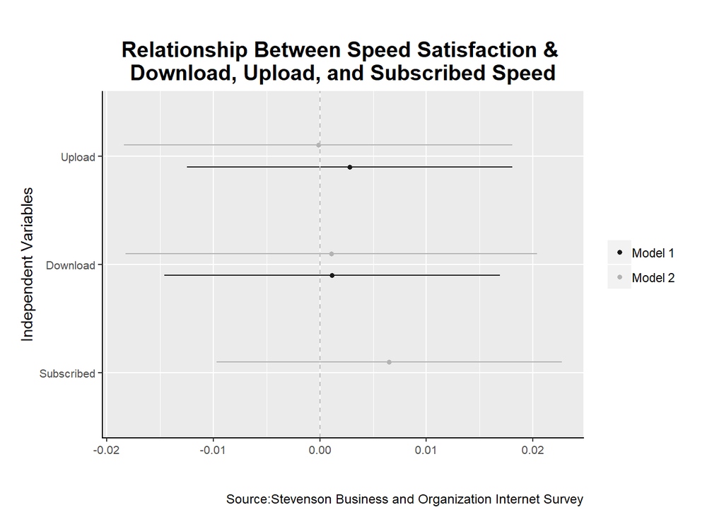

```r
# plotting models and adding/changing theme/text elements
dwplot(allModels) +
  geom_vline(xintercept = 0,
               colour = "grey",
               linetype = 2) +
  scale_colour_grey(start = .1, end = .7) +
  labs(y = "Independent Variables",
title = "Relationship Between Speed Satisfaction &
Download, Upload, and Subscribed Speed",
         caption = "Source:Stevenson Business and Organization Internet Survey") +
  theme(plot.margin=unit(c(1,1,.5,.5),'cm'),
                    plot.title=(element_text(face='bold',
                                            size=15,
                                            hjust=0.5)),
                    plot.subtitle = (element_text(hjust = 0.5, vjust = 2)),
                    plot.caption=element_text(size=9, vjust=-2),
                    text=element_text(color='black', size = 11),
                    legend.title = element_blank(),
                    axis.line.y=element_line(color = 'black'),
                    axis.line.x=element_line(color='black'),
                    axis.text=element_text(size=8))
```

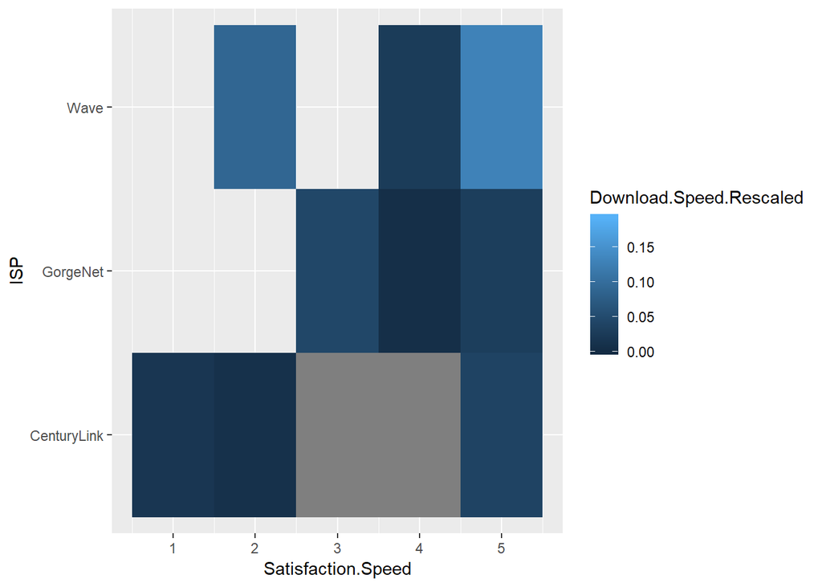

```r
##Heatmap

library(scales)
library(ggplot2)

#loading data
link='https://github.com/marcevl/Team-Assignments/raw/master/Internet2.RData'
load(file=url(link))

#changing download speed to a variable from 0-1
Internet2$Download.Speed.Rescaled <- rescale(Internet2$Download.Speed)

#adding data to data frame
df1 <- Internet2

#removing obervation with outlier
df1 <- df1[-3,]

#removing unnecessary variables from heatmap data frame
df.heatmap <- df1[c(2,6,10,40)]

#removing ISPs without many observations
df.heatmap <- subset(df.heatmap, ISP %in% c("Wave", "CenturyLink", "GorgeNet"))

#plotting heat map
heat1 = ggplot(data = df.heatmap, aes(x = Satisfaction.Speed, y = ISP)) +
  geom_tile(aes(fill = Download.Speed.Rescaled))

heat1
```

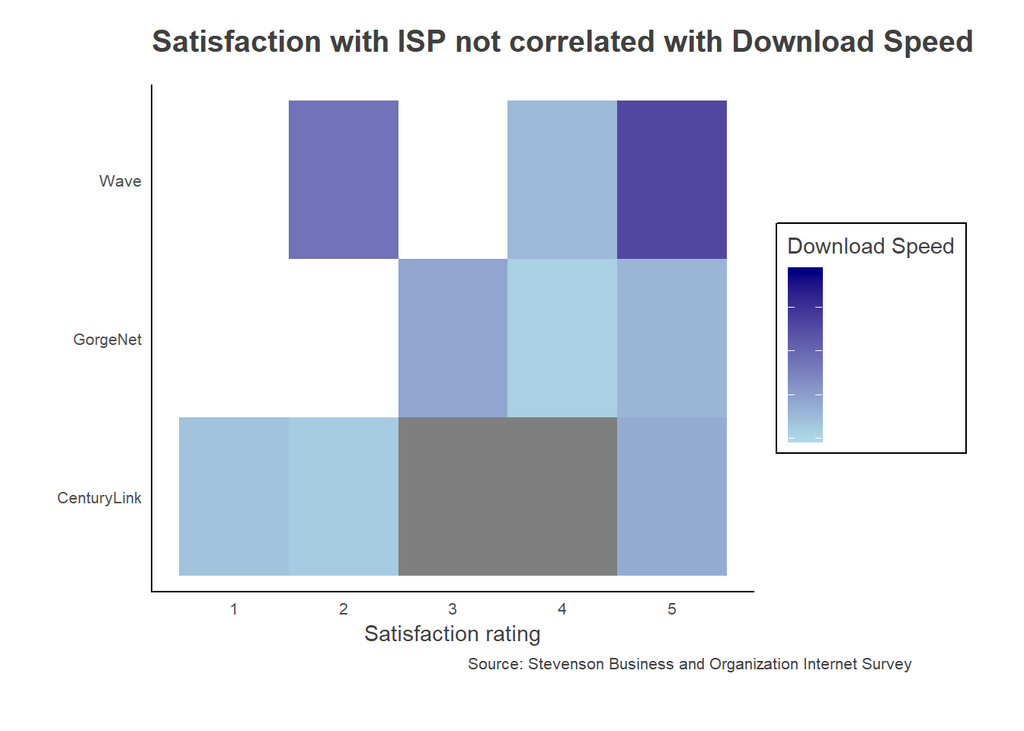

```r
#Adding theme elements
heat1 = heat1 + labs(title='Satisfaction with ISP not correlated with Download Speed',
            y=NULL,
            x='Satisfaction rating',
            caption='Source: Stevenson Business and Organization Internet Survey',
            fill='Range of \nDownload Speeds')

heat2 = heat1 + theme(plot.margin=unit(c(.5,1,1,1),'cm'),
                    plot.title=(element_text(face='bold',
                                            size=15,
                                            hjust=0,
                                margin=unit(c(0,0,.5,0),'cm'))),
                    plot.subtitle = (element_text(hjust = 0.5, vjust = 2)),
                    plot.caption=element_text(size=8, hjust=2),
                    legend.text=element_blank(),
                    legend.background=element_rect(linetype='solid',
                                                   color='black'),
                    panel.background=element_rect(fill='white'),
                    text=element_text(color='gray25', size = 11),
                    axis.line.y=element_line(color = 'black'),
                    axis.line.x=element_line(color='black'),
                    axis.ticks=element_blank(),
                    axis.text=element_text(size=8))

heat2 + scale_fill_gradient(low='lightblue',high='navy',
                            guide_colorbar(reverse=TRUE,
                                           title='Download Speed'))
```

We realized after working with a heatmap that it was not appropriately displaying the information we wanted to present. Instead of looking for correlation between variables, we chose variables we thought woudl be correlated and plotted them. This led to the not-so-interesting results above. We decided that a correlation plot would be more helpful. Those plots, which are included in our final report, are below.

```r
#The first step is to create a new dataframe with the variables of interest

#Add data to dataframe and removing outlier observation in row 3
df1 <- Internet2[-3,]

#Add relevant variables to new dataframe
df.corr <- df1[,c('ISP','Cost','Subscribed.Speed','Download.Speed','Upload.Speed', 'Satisfaction.Speed', 'Satisfaction.Price','Satisfaction.Reliability','Satisfaction.Customer.Service','Satisfaction.Overall','Ease.Streaming','Ease.Downloading','Speed.Difficulty')]
```

```r
#We need to convert the values for satisfaction ('Dissatisfied','Satisfied', etc.), cost, and ease ('Easy','Difficult', etc.)  into numeric factors so we can plot them compare them to each other
df.corr$Cost <- as.integer(as.factor(df.corr$Cost))
df.corr$Satisfaction.Price <- as.integer(as.factor(df.corr$Satisfaction.Price))
df.corr$Satisfaction.Reliability <- as.integer(as.factor(df.corr$Satisfaction.Reliability))
df.corr$Satisfaction.Customer.Service <- as.integer(as.factor(df.corr$Satisfaction.Customer.Service))
df.corr$Satisfaction.Overall <- as.integer(as.factor(df.corr$Satisfaction.Overall))
df.corr$Ease.Streaming <- as.integer(as.factor(df.corr$Ease.Streaming))
df.corr$Ease.Downloading <- as.integer(as.factor(df.corr$Ease.Downloading))
df.corr$Speed.Difficulty <- as.integer(as.factor(df.corr$Speed.Difficulty))
```

Now we can plot this new dataframe (df.corr)

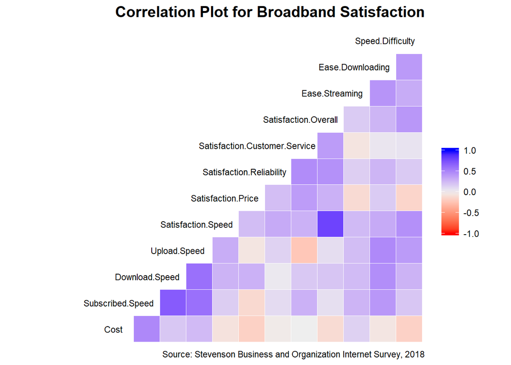

```r
#Call up the appropriate library
library(GGally)

#Visualize the data onto a correlation plot
corrplot = ggcorr(df.corr[,-1], # all but the first column
       hjust = 0.9,# distance to plot (diagonal)
       size=3, # font size
       layout.exp=3, # width so that variable names are shown
       low = 'red',high = 'blue') # color scale

#Add a title and caption
corrplot1 = corrplot + labs(title='Correlation Plot for Broadband Satisfaction',
                   caption='Source: Stevenson Business and Organization Internet Survey, 2018')

#Adjust the theme
corrplot2 = corrplot1 + theme(plot.title=(element_text(face='bold', #Bold title
                                            size=15, #Font size
                                            hjust=1)), #title Horizontal alignment
                              plot.caption=(element_text(hjust=1))) #Caption horizontal alignment

#Print the plot
corrplot2
```

Here, higher positive correlation will apear more blue (1) while negative correlations will appear more organe (-1). While this plot is helpful, the multiple variables that measure satisfaction adds confusion. Instead, we can look at just ‘Overall Satisfaction’ and see if it is associated with any of the explanatory variables.

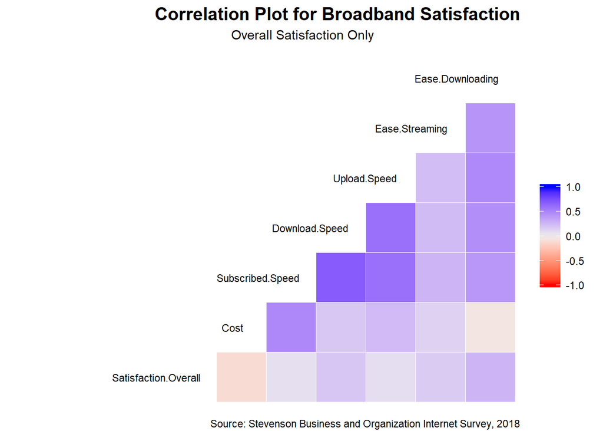

```r
#Creating a new dataframe with only one variable measuring satisfaction
df.corr2 <- df.corr[,c('ISP','Satisfaction.Overall','Cost','Subscribed.Speed','Download.Speed','Upload.Speed','Ease.Streaming','Ease.Downloading')]

#Same steps as the previous plot, but with the new dataframe (df.corr2)
corrplot3 = ggcorr(df.corr2[,-1],
       hjust = 0.9,
       layout.exp=3,
       size=3,
       low = 'red',high = 'blue')

corrplot4 = corrplot3 + labs(title='Correlation Plot for Broadband Satisfaction',
                             subtitle='Overall Satisfaction Only',
                   caption='Source: Stevenson Business and Organization Internet Survey, 2018')

corrplot5 = corrplot4 + theme(plot.title=(element_text(face='bold',
                                            size=15,
                                            hjust=1)),
                              plot.subtitle=(element_text(hjust=.6)),
                              plot.caption=(element_text(hjust=1, vjust = -1)))

corrplot5
```

This plot tells us more about the relationship between Satisfaction and the other variables. The cell with the largest negative correlation is the interaction between ‘Satisfaction.Overall’ and ‘Cost’; this indicates that people who pay more for their internet service tend to be less satisfied. The greatest positive correlation is between ‘Satisfaction.Overall’ and ‘Ease.Downloading’, which indicates that people who rate the difficulty of downloading lower are more satisfied overall with their ISP.